# Personal Data Project

Kyi Yeung Goh

21/02/2019

This project started out when I started noticing ads that were catered to my taste and preferences almost immediately after certain purchases on my card. Indeed, as a consumer, I felt a need to better understand where I left my digital footprints and at the same time, analyse how that affects the amount and type of ad information I am exposed to.

Much has been made of the lack of regulation regarding collection of ‘big data’ in recent years. With recent policy developments in the European Union in the form of the General Data Protection Regulation (GDPR), some progress has been made to safeguard consumer privacy and the misuse of their digital information. The use or misuse of this information was the subject of a recent [Financial Times podcast](https://www.ft.com/content/9fb4c0ed-c941-4ac3-88b8-9c990e494659). 3rd-party data brokers often operate freely in the grey area that exists due to insufficient legal protections for consumer in the era of the internet-of-things, where any object linked to the net can be harnessed to better understand their users. Indeed, the [New York Times published an article](https://www.nytimes.com/interactive/2018/12/10/business/location-data-privacy-apps.html) on company’s use of geolocation data to predict consumer habits.

To faciliate this project, I switched on all ad personalisation and tracking functions on all social media platforms on my phone.Over the period of 10 days, I collected information regarding:

- All transactions made on my card including the type of items
- Location and time spent at locations
- Ad information: type of ad, company and location where it was viewed

Process:

1. Collated data
2. Initial sketches
3. Data journey: exploration insights, thought processes and conceptualisation
4. Final visualisations
5. Conclusion

Interestingly, the 10-day period coincided with the Superbowl as well as the Oscars which noticeably affected the ads I viewed.

## 1. Quick interactive data overview

```r
datatable(dv_data, options = list(pageLength = 15, scrollX=TRUE,autoWidth = TRUE, caption = 'Quick interactive table with collected data'))
```

|  | DAY | ADVERTS | PLATFORM | LOCATION | SPENDING | CLASS | FOOD | CLOTHING | LIFESTYLE | DRINKS | WORK |
| --- | --- | --- | --- | --- | --- | --- | --- | --- | --- | --- | --- |
| 1 | 1 | Honda cars | Instagram | Mountain Province | 24.5 | Lifestyle | 16.1 | 0 | 4.99 | 3.41 | 0 |
| 2 | 1 | Hersheys | Instagram | Mountain Province | 24.5 | Food | 16.1 | 0 | 4.99 | 3.41 | 0 |
| 3 | 1 | Real estate | Instagram | Mountain Province | 24.5 | Lifestyle | 16.1 | 0 | 4.99 | 3.41 | 0 |
| 4 | 1 | Stella Artois | Instagram | Mountain Province | 24.5 | Drinks | 16.1 | 0 | 4.99 | 3.41 | 0 |
| 5 | 1 | Belvita | Instagram | Mountain Province | 24.5 | Food | 16.1 | 0 | 4.99 | 3.41 | 0 |
| 6 | 1 | Gearpatrol | Instagram | Mountain Province | 24.5 | Clothing | 16.1 | 0 | 4.99 | 3.41 | 0 |
| 7 | 1 | Dietz and watson | Twitter | Mountain Province | 24.5 | Food | 16.1 | 0 | 4.99 | 3.41 | 0 |
| 8 | 1 | Showtime | Twitter | Mountain Province | 24.5 | Lifestyle | 16.1 | 0 | 4.99 | 3.41 | 0 |
| 9 | 1 | Oreos | Twitter | Mountain Province | 24.5 | Food | 16.1 | 0 | 4.99 | 3.41 | 0 |
| 10 | 1 | Cheezit | Twitter | Mountain Province | 24.5 | Food | 16.1 | 0 | 4.99 | 3.41 | 0 |

[output cut: 107 more lines]

## Initial thought processes and sketches

Prior to obtaining the data, I thought about potential ways to visualise it (Figure 1).

[figure not shown]

Initial sketches

**TOP LEFT**: This sketch lays out the data I have using the MTA subway lines that I travel on as a guide. The stops which I frequent help to ground and contextualise my spending and perhaps the advertisements I view around the site. Given that there are many random locations which I go to, a cluster might be used. Each location has a speech bubble which will provide a piechart of how much the area constituted in total spending and the breakdown as well as advertisement data.

**TOP RIGHT**: I mirror a bar chart, using the x-axis as the breakpoint. The +ve y-axis tracks amount spent while the –ve x-axis looks at number of advertisement seen. The x-axis tracks the days. These bars will then be further refined to split into spending categories.

**BOTTOM LEFT**: This takes the concept in the TOP RIGHT model but has a line graph for the +ve y-axis. There will be a line at the just above the x-axis which will place locations where I spent the money as circles, matching the peaks and troughs accordingly. The –ve y-axis remains the same.

**BOTTOM RIGHT**: This repackages what I have actually spent versus what the Internet thinks I should spend. The left will take the proportion of my spending (based on categories that I have predefined) and the right side will be the proportion of advertisement shown based on the same categories.

## 3. Data journey: exploration insights, thought processes and conceptualisation

### Number of adverts viewed per day

```r
dv_data%>%
  group_by(DAY)%>%
  summarise(no_adv=length(DAY))
```

```
## # A tibble: 10 x 2
##      DAY no_adv
##    <dbl>  <int>
##  1     1     29
##  2     2      6
##  3     3      5
##  4     4      2
##  5     5     14
##  6     6      5
##  7     7     12
##  8     8     12
##  9     9     21
## 10    10     11
```

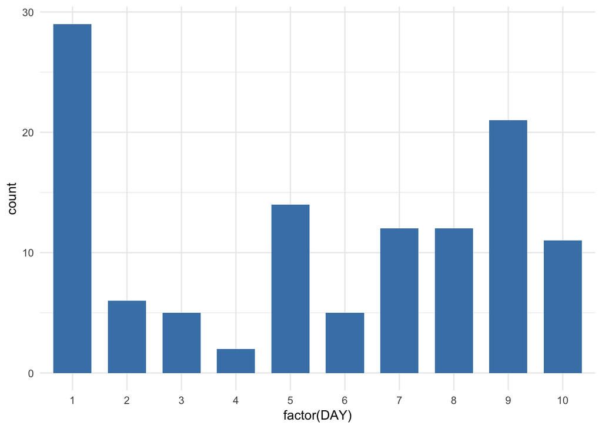

```r
ggplot(dv_data, aes(x=factor(DAY)))+
  geom_bar(stat="count", width=0.7, fill="steelblue")+
  theme_minimal()
```

On average, I am aware that I am exposed to around 11.7 mobile ads on social media.

## Type of advertisements by day

For the purpose of this project, I grouped advertisements into 6 categories of lifestyle, food, drinks, clothing and drugs. In this plot, I grouped the visualisations by class and proceeded to plot them over time. In this case, I observe that I am getting a fair number of advertisements related to food and lifestyle.

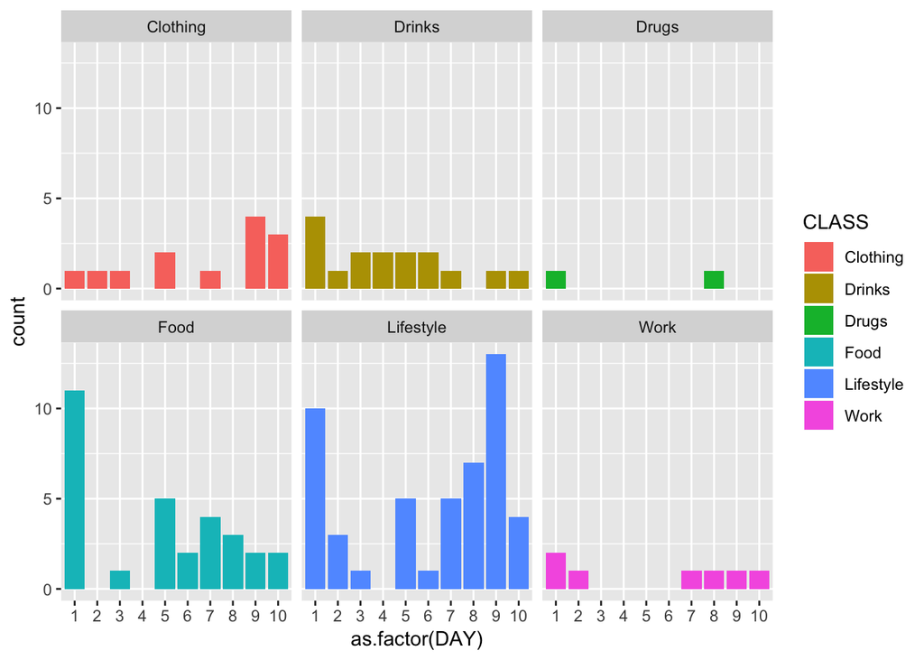

```r
ggplot(dv_data) +
  geom_bar(aes(x = as.factor(DAY), fill = CLASS)) +
  facet_wrap(~ CLASS)
```

```r
count_adv<-dv_data %>%
  group_by(CLASS) %>%
  summarise(count = length(CLASS))

data.table(count_adv)
```

```
##        CLASS count
## 1:  Clothing    13
## 2:    Drinks    16
## 3:     Drugs     2
## 4:      Food    30
## 5: Lifestyle    49
## 6:      Work     7
```

## Amount spent per day

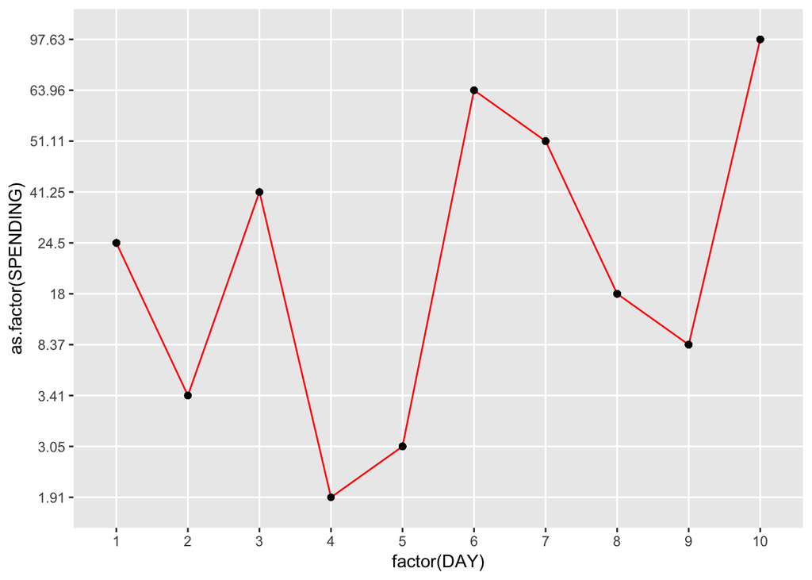

```r
spend<-dv_data%>%
  group_by(as.factor(SPENDING))

ggplot(data=dv_data, aes(x=factor(DAY), y=as.factor(SPENDING), group=1)) +
  geom_line(color="red")+
  geom_point()
```

## Amount spent per day (by category)

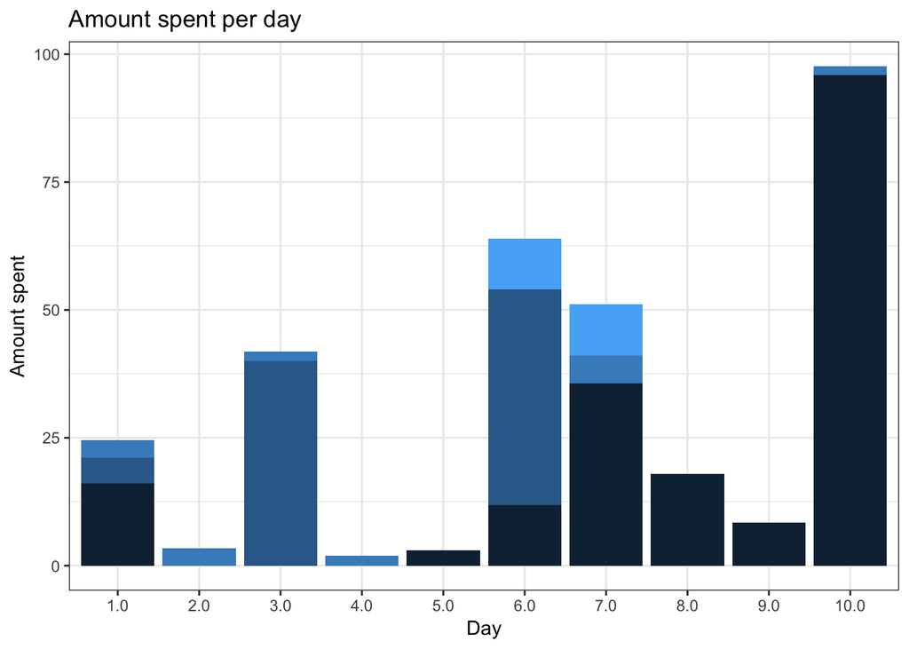

```r
spending_data$X__1<-NULL
spending_data<-spending_data[-c(6),]
spending_data$row <- seq_len(nrow(spending_data))
dat2 <- melt(spending_data, id.vars = "row")

ggplot(dat2, aes(x = variable, y = value, fill = row)) +
  geom_bar(stat = "identity") +
  xlab("Day") +
  ylab("Amount spent") +
  guides(fill = FALSE) +
  ggtitle("Amount spent per day")+
  theme_bw()
```

After looking at the above plots, I decided on the MTA visualisation: I found this to be interesting as it allowed me to get a sense of spending and viewing over space with a location element. This was important as location often shapes the ads I view.

## Number of ads viewed by place

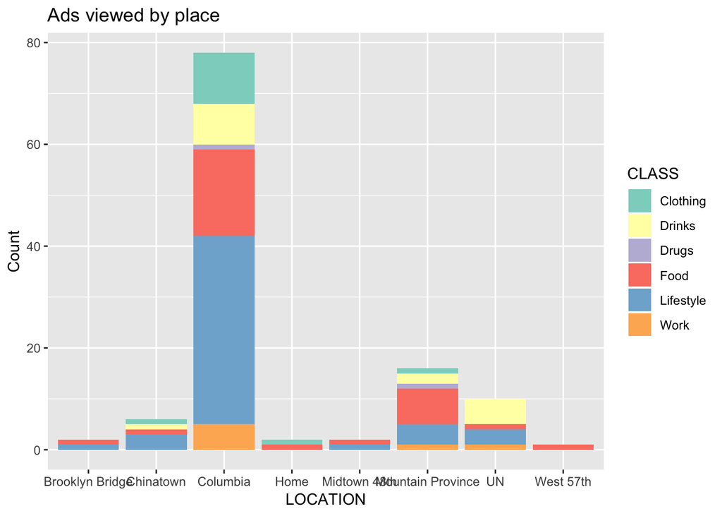

```r
### Number of adverts viewed per day
general_count<-dv_data%>%
  group_by(LOCATION,CLASS)%>%
  summarise(count=n())


ggplot(general_count, aes(fill=CLASS, y=count, x=LOCATION)) +
    geom_bar( stat="identity")+
  scale_fill_brewer(palette = "Set3") +
  ylab("Count") +
  ggtitle("Ads viewed by place")
```

```r
spending_count<-dv_data%>%
  group_by(DAY,SPENDING)%>%
  summarise(sum(SPENDING))

aggregate(spending_count$SPENDING, by=list(Category=spending_count$DAY), FUN=sum)
```

```
##    Category     x
## 1         1 24.50
## 2         2  3.41
## 3         3 41.25
## 4         4  1.91
## 5         5  3.05
## 6         6 63.96
## 7         7 51.11
## 8         8 18.00
## 9         9  8.37
## 10       10 97.63
```

# Final Sketch

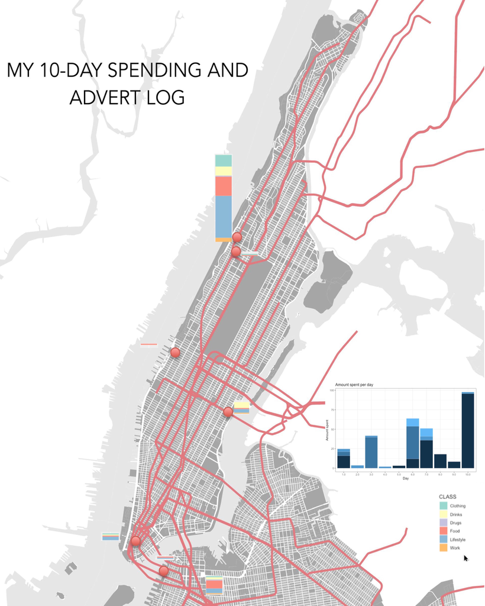

Final sketches

Here, I used several shape files to create a map of NY, providing detail only to areas I travelled to. The colored stacked bar graphs are placed next to the relevant locations. They represent the amount of advertisements I viewed with the colors in the barchart representing the categories of advertisement per area. In this case, I included a legend on the bottom right to guide the user. I also included a spending chart that looked at my spending over time, with the shades of blue representing different spending categories - very dark blue for food, dark blue for lifestyle, medium blue for drinks and lightest blue for work. I realised that the manner in which I collected the data affected the visualisations I could do. By collecting the amount I spend without the corresponding place where I spent stopped me from making a meaningful side-by-side barchart. Nonetheless, this was an important learning point. I made a design choice by making the locations pseudo-anonymous by not providing the name but with some degree of inference, one could easily figure out those places. In a sense, this is a metaphor for how data collection works. It may be anonymous but only to the extent that the inferences are not driven by finding the identity of that person on a micro scale.